# Classification model - Support Vector Machines (SVM)

Ema Richnakova

2024-04-17

## Importing Libraries

```r
library(magrittr)
library(tidyverse)
```

```r
library(dplyr) # mutate
library(e1071) # for SVM
library(pROC) # roc() - create ROC curve
library(caret) # confusion matrix
```

## Loading the Dataset

```r
data <- read_csv("spotify_top_songs_audio_features.csv", col_names = TRUE, num_threads = 4)
head(data)
```

```
## # A tibble: 6 × 19
##   id      artist_names track_name source key   mode  time_signature danceability
##   <chr>   <chr>        <chr>      <chr>  <chr> <chr> <chr>                 <dbl>
## 1 000xQL… ZAYN, PARTY… Still Got… RCA R… G     Major 4 beats               0.748
## 2 003eoI… Alessia Cara Growing P… Def J… C#/Db Minor 4 beats               0.353
## 3 003vvx… The Killers  Mr. Brigh… Islan… C#/Db Major 4 beats               0.352
## 4 00B7TZ… Cardi B, Ch… Best Life… Atlan… A     Major 4 beats               0.62
## 5 00Blm7… Post Malone… One Right… Repub… C#/Db Major 4 beats               0.687
## 6 00EPIE… Thalia, NAT… No Me Acu… Sony … G     Minor 4 beats               0.836
## # ℹ 11 more variables: energy <dbl>, speechiness <dbl>, acousticness <dbl>,
## #   instrumentalness <dbl>, liveness <dbl>, valence <dbl>, loudness <dbl>,
## #   tempo <dbl>, duration_ms <dbl>, weeks_on_chart <dbl>, streams <dbl>
```

## Data exploration

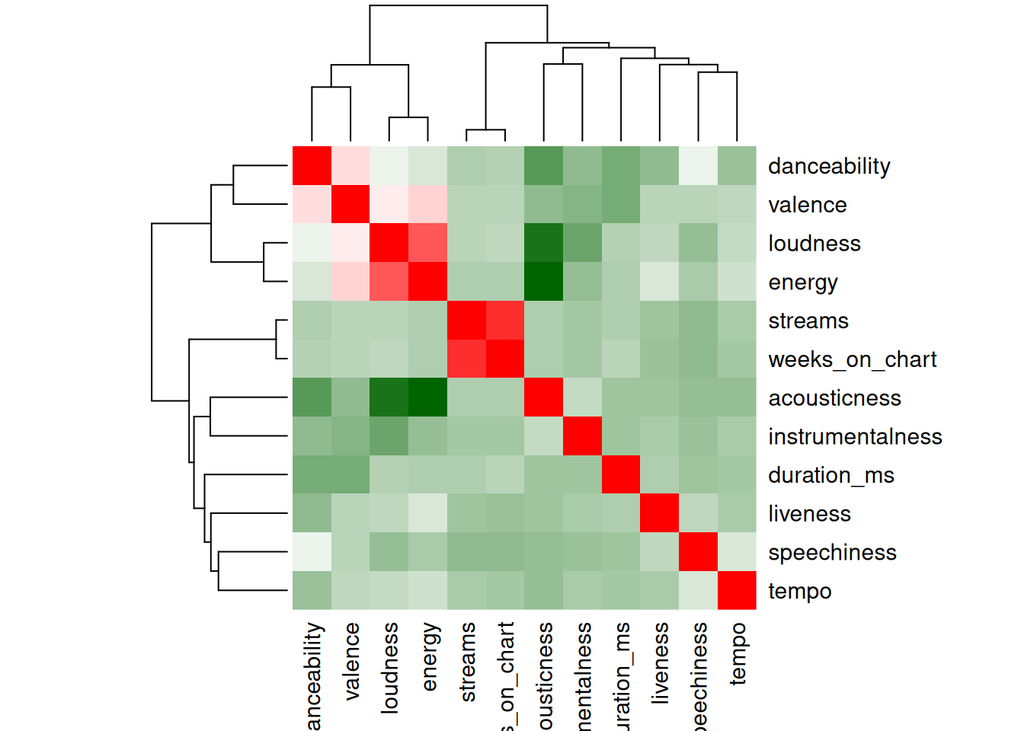

```r
heatmap(cor(data %>% select_if(is.numeric)),
        col = colorRampPalette(c("darkgreen", "white", "red"))(100),
        symm = TRUE)
```

### Hypothesis 1

*Songs classified as more energetic (>=0.64)(1) are more likely to be louder and happier compared to songs classified as less energetic (<0.64)(class 0).*

```r
mean_energy <- mean(data$energy) ; mean_energy
```

```
## [1] 0.6365223
```

```r
class_data <- data %>%
  mutate(energy = ifelse(energy >= mean_energy, 1, 0)) %>%
  select_if(is.numeric)
head(class_data)
```

```
## # A tibble: 6 × 12
##   danceability energy speechiness acousticness instrumentalness liveness valence
##          <dbl>  <dbl>       <dbl>        <dbl>            <dbl>    <dbl>   <dbl>
## 1        0.748      0      0.0639      0.131                  0   0.0852   0.524
## 2        0.353      1      0.733       0.0822                 0   0.39     0.437
## 3        0.352      1      0.0747      0.00121                0   0.0995   0.236
## 4        0.62       0      0.553       0.287                  0   0.314    0.665
## 5        0.687      1      0.053       0.0361                 0   0.0755   0.688
## 6        0.836      1      0.0873      0.187                  0   0.092    0.772
## # ℹ 5 more variables: loudness <dbl>, tempo <dbl>, duration_ms <dbl>,
## #   weeks_on_chart <dbl>, streams <dbl>
```

Using energy mean as threshold for classification is beneficial for top Spotify songs dataset, where higher energy levels are prevalent. Classification classes are more balanced.

```r
table(class_data$energy)
```

```
##
##    0    1
## 3021 3492
```

## Classification model - Support Vector Machine (SVM)

### Why SVM?

SVM preforms well in high-dimensional spaces, making it suitable for dataset with many features. Also it aims to find best decision boundary, that maximizes margin between classes (reduces overfitting). Performs well by focusing on the most informative features. It can also handle inbalanced datasets, but our classification solves this issue already.

### Prepare data for SVM

SVM model does not require normally distributed data. However, it is crucial to properly scale input data. Scale of song features can influence decision boudnaries of SVM, thereby affecting its optimal performance.

Common practice is to scale input to similar range (e.g. 0-1) before training.

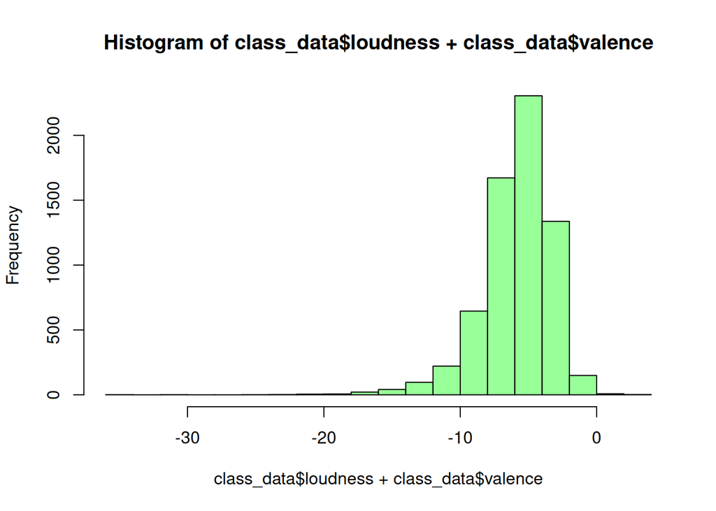

```r
hist(class_data$loudness + class_data$valence, col = "#99ff99") # hypergeometric distribution
```

Range of loudness:

```r
range(class_data$loudness)
```

```
## [1] -34.475   1.509
```

Range of valence:

```r
range(class_data$valence)
```

```
## [1] 0.032 0.982
```

Valence values are already normalized, but we scale it also with loudness, so both have min=0 and max=1.

#### Scaling

```r
min_max_scale <- function(x, min_val, max_val) {
  (x - min_val) / (max_val - min_val)
}
class_data <- class_data %>%
  mutate(
    loudness = min_max_scale(loudness, min(loudness), max(loudness)),
    valence = min_max_scale(valence, min(valence), max(valence))
  )
```

New range of loudness:

```r
range(class_data$loudness)
```

```
## [1] 0 1
```

New range of valence:

```r
range(class_data$valence)
```

```
## [1] 0 1
```

### Sampling

```r
sample <- sample(c(TRUE, FALSE), nrow(class_data), replace = TRUE, prob = c(0.7, 0.3))
train_data <- class_data[sample, ]
test_data <- class_data[!sample, ]
```

### Train SVM model

```r
model_svm <- svm(as.factor(energy) ~ loudness + valence, data = train_data, kernel = "linear", cost = 10, scale = FALSE)
# higher cost -> more complex decision boundary -> penalizes misclassification
# scale = FALSE -> inputs are already scaled, so scalling in SVM can be disabled
summary(model_svm)
```

```
##
## Call:
## svm(formula = as.factor(energy) ~ loudness + valence, data = train_data,
##     kernel = "linear", cost = 10, scale = FALSE)
##
##
## Parameters:
##    SVM-Type:  C-classification
##  SVM-Kernel:  linear
##        cost:  10
##
## Number of Support Vectors:  2478
##
##  ( 1240 1238 )
##
##
## Number of Classes:  2
##
## Levels:
##  0 1
```

```r
# number of support vectors -> support vectors are data points that lies closest
# to decision boundary and influence placement of decision boundary.
coefs <- coef(model_svm) ; coefs # weight of each feature to predict TP/N
```

```
## (Intercept)    loudness     valence
##  -17.497268   21.455780    1.732734
```

```r
model_svm$rho
```

```
## [1] 17.49727
```

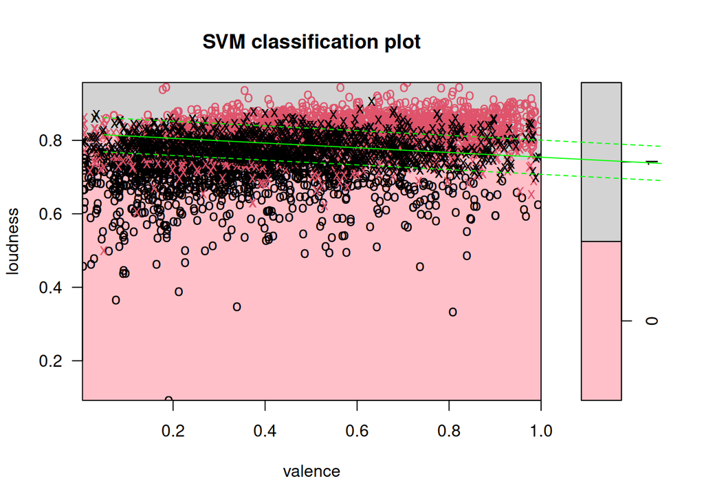

```r
# (+ coef - higher chance of class 1, - coef - opposite)
plot(model_svm, train_data, loudness ~ valence, col = c("#ffc0c9", "lightgrey"))
abline(-coefs[1] / coefs[2], (-coefs[3] / coefs[2]), col = "green")
abline((-coefs[1] - 1) / coefs[2], -coefs[3] / coefs[2], lty = 2, col = "green")
abline((-coefs[1] + 1) / coefs[2], -coefs[3] / coefs[2], lty = 2, col = "green")
```

```r
# ablines from https://www.datacamp.com/tutorial/support-vector-machines-r
```

### Test SVM model

```r
predicted_classes <- predict(model_svm, newdata = test_data, decision.values = TRUE)
decision_values <- attr(predicted_classes, "decision.values")[, 1]
head(decision_values) # signed distance of each data point to the decision boundary
```

```
##          1          2          3          4          5          6
##  0.3612864  0.3124053 -0.2216682  1.8761545 -1.0563049 -1.1412441
```

```r
# confidence of the model in its prediction
```

#### ROC curve

```r
roc <- roc(test_data$energy, decision_values)
```

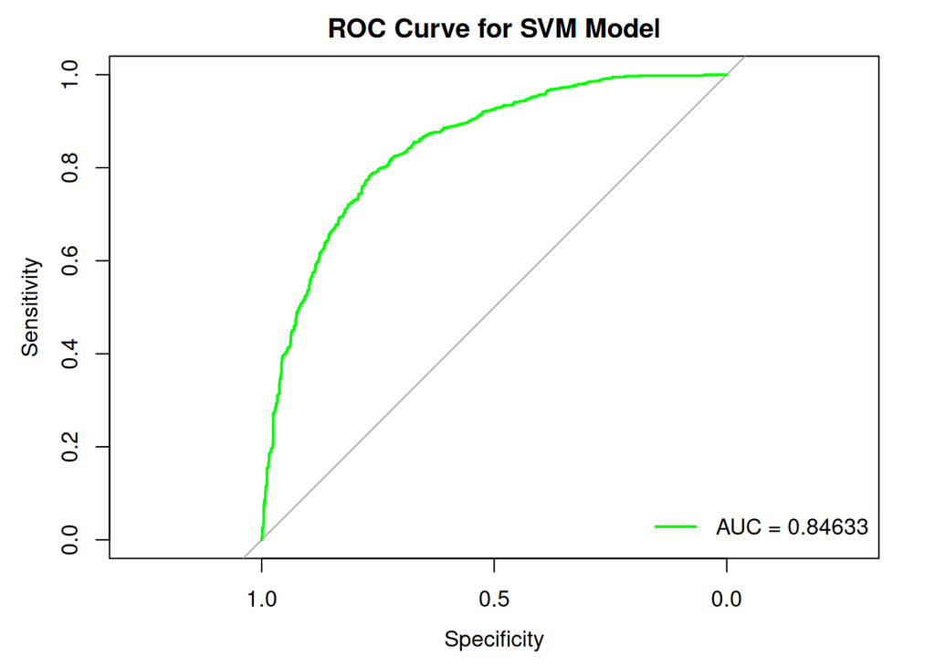

```r
plot(roc, main = "ROC Curve for SVM Model", col = "green", lwd = 2)
legend("bottomright", legend = paste("AUC =", round(auc(roc), 5)), col = "green", lwd = 2, bty = "n")
```

## Evaluation of SVM

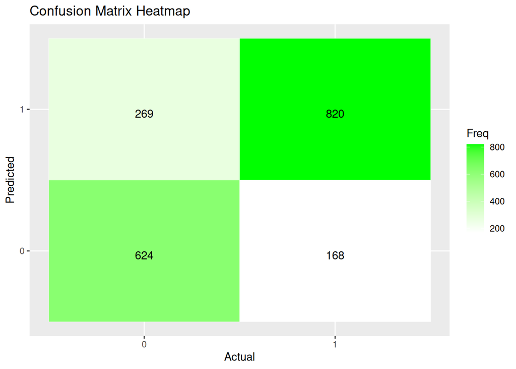

```r
confusion_matrix <- caret::confusionMatrix(as.factor(predicted_classes), as_factor(test_data$energy), positive = "1")
ct <- confusion_matrix$table

TP <- ct[2, 2] # true positive
FP <- ct[2, 1] # false positive
TN <- ct[1, 1] # true negative
FN <- ct[1, 2] # false negative
P <- TP + FN # all positives (1)
N <- FP + TN # all negatives (0)

# confusion matrix heatmap
ggplot(as.data.frame(ct), aes(x = Reference, y = Prediction, fill = Freq)) +
  geom_tile(color = "white") +
  geom_text(aes(label = Freq), vjust = 1) +
  scale_fill_gradient(low = "white", high = "green") +
  labs(x = "Actual", y = "Predicted", title = "Confusion Matrix Heatmap")
```

```r
print(paste("Accuracy: ", (TP + TN) / (P + N)))
```

```
## [1] "Accuracy:  0.767676767676768"
```

```r
print(paste("Proportion of class 1: ", P / (P + N)))
```

```
## [1] "Proportion of class 1:  0.525252525252525"
```

```r
print(paste("Proportion of class 0: ", N / (P + N)))
```

```
## [1] "Proportion of class 0:  0.474747474747475"
```

```r
precision <- TP / (FP + TP)
print(paste("Precision: ", precision))
```

```
## [1] "Precision:  0.752984389348026"
```

```r
recall <- TP / P
print(paste("Recall: ", recall))
```

```
## [1] "Recall:  0.82995951417004"
```

```r
f1_score <- 2 * (precision * recall) / (precision + recall)
print(paste("F1 score: ", f1_score))
```

```
## [1] "F1 score:  0.78960038517092"
```

```r
print(paste("Specificity: ", TN / (TN + FP)))
```

```
## [1] "Specificity:  0.698768197088466"
```